# Quality Management Plan, Quarterly Report for Quarter 4, 2017 – Red

Generated on 03/21/18

All assessments included in this plan were completed between 2015-01-21 and 2017-10-27, using data entered as of 2017-10-27.

## Screener Timeliness

The following graphs report by cohort year and quarter on the percent of clients who received an on-time screener (within 10 business days of referral). Each point on the graph indicates the percent of persons in a given quarter who received an on-time screener.

**Note** that there may be fewer cohort years represented than exist in the date, as this report does not display any information calculated off of groups of clients smaller than 10. While there are clients being served in these cohorts, those reports are suppressed.

### By Quarter

**A graph cannot be generated, because there were no quarters in which 10 or more clients were enrolled and received screeners.**

### By Quarter, Contrasting Year

**A graph cannot be generated, because there were no quarters in which 10 or more clients were enrolled and received screeners.**

## Full Assessment Timeliness

The following graphs report by cohort year and quarter on the percent of clients who received an on-time assessment (within 30 days of the last initial screener). Each point on the graph indicates the percent of persons in a given quarter who received an on-time full assessment.

**Note** that there may be fewer cohort years represented than exist in the date, as this report does not display any information calculated off of groups of clients smaller than 10. While there are clients being served in these cohorts, those reports are suppressed.

### By Quarter

**A graph cannot be generated, because there were no quarters in which 10 or more clients were enrolled.**

### By Quarter, Contrasting Year

**A graph cannot be generated, because there were no quarters in which 10 or more clients were enrolled.**

## Treatment Needs at Entry

The graphs below report point-in-time (at Initial assessment) and comparison-across-time (between Initial and reassessment) percentages of clients experiencing particular actionable needs (items rated as a ‘2’ or ‘3’) on the CANS.

**Note** that there may be fewer assessment periods represented in this series of graphs than just above. This is a consequence of the fact that this report does not display any information calculated off of groups of clients smaller than 10. While there are clients being served at these later periods, those reports are suppressed.

### Across All Clients

#### 2015 Cohort

##### Initial

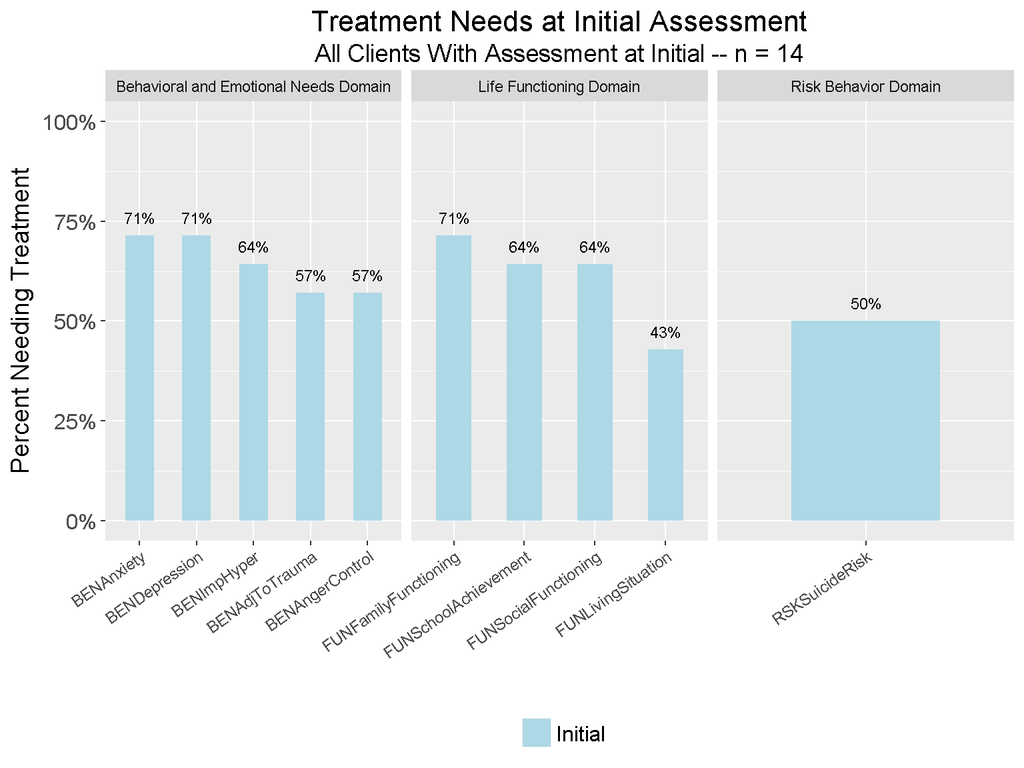

##### 3mo

**A graph cannot be generated, because in the given cohort year and sample, fewer than 10 clients were assessed.**

##### 6mo

**A graph cannot be generated, because in the given cohort year and sample, fewer than 10 clients were assessed.**

##### 9mo

**A graph cannot be generated, because in the given cohort year and sample, fewer than 10 clients were assessed.**

##### 15mo

**A graph cannot be generated, because in the given cohort year and sample, fewer than 10 clients were assessed.**

##### 18mo

**A graph cannot be generated, because in the given cohort year and sample, fewer than 10 clients were assessed.**

#### 2016 Cohort

##### Initial

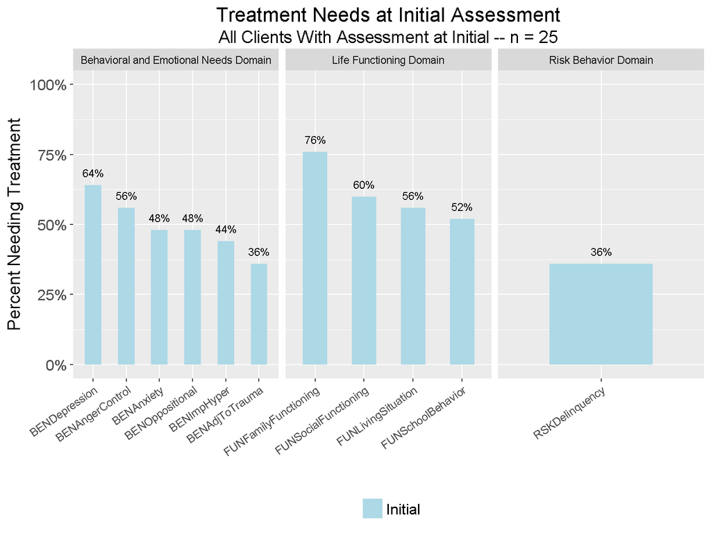

##### 3mo

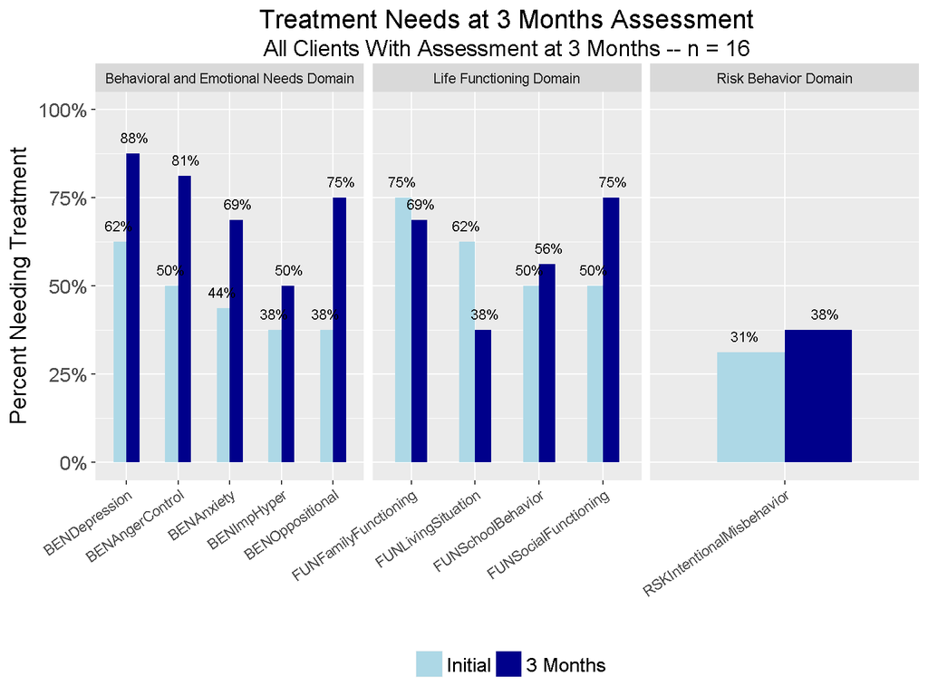

##### 6mo

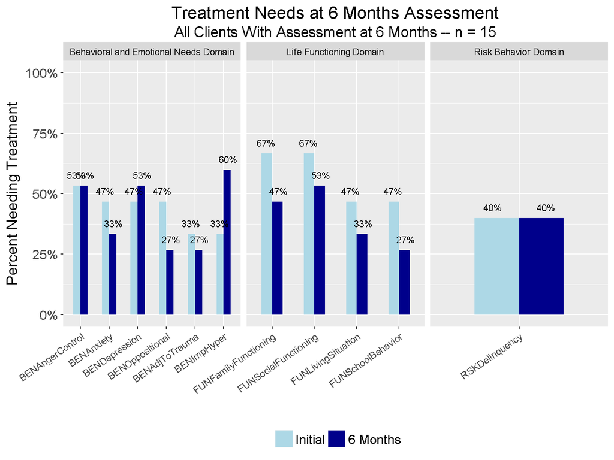

##### 9mo

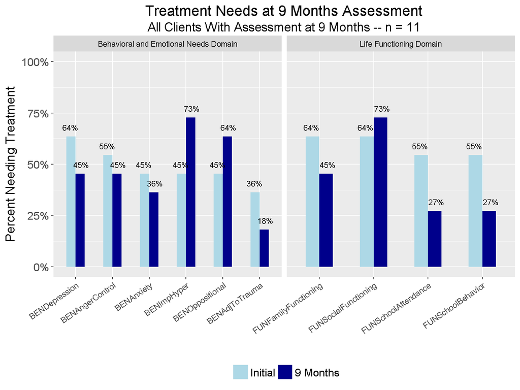

##### 12mo

**A graph cannot be generated, because in the given cohort year and sample, fewer than 10 clients were assessed.**

##### 15mo

**A graph cannot be generated, because in the given cohort year and sample, fewer than 10 clients were assessed.**

##### 18mo

**A graph cannot be generated, because in the given cohort year and sample, fewer than 10 clients were assessed.**

#### 2017 Cohort

##### Initial

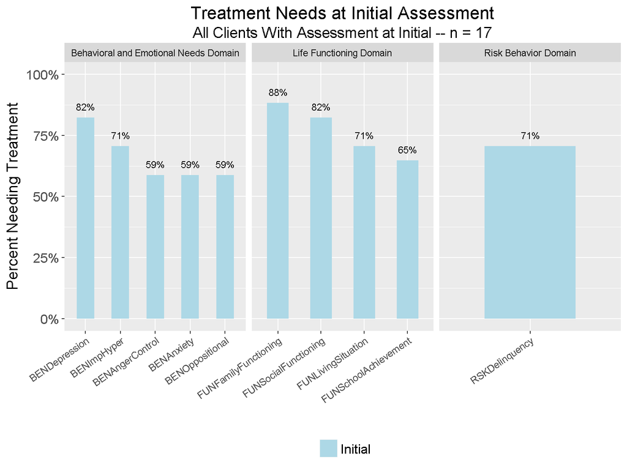

##### 3mo

**A graph cannot be generated, because in the given cohort year and sample, fewer than 10 clients were assessed.**

#### All Cohort

##### Initial

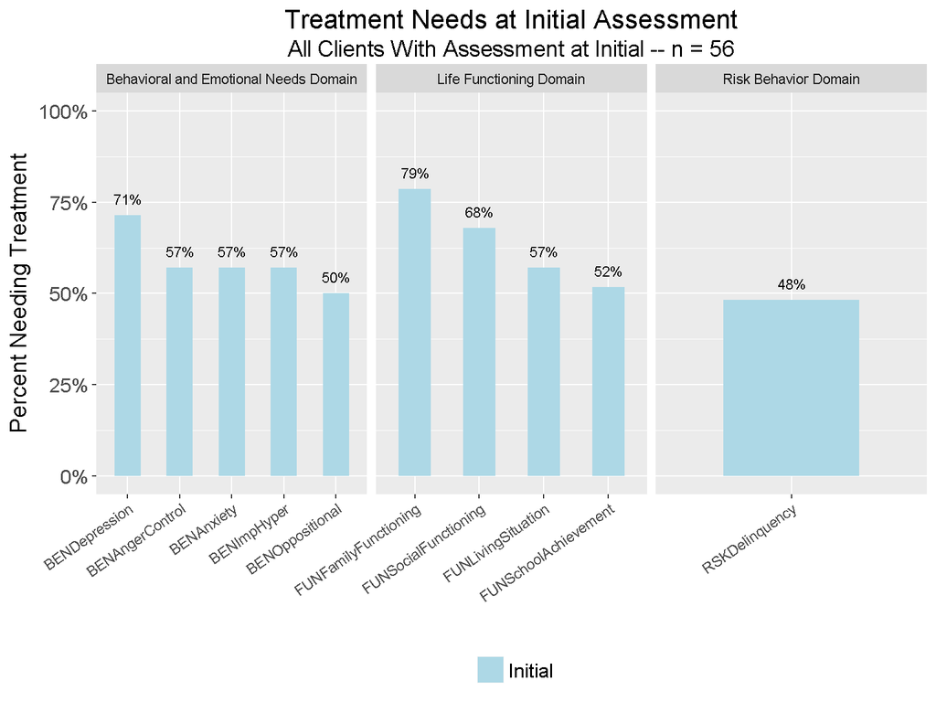

##### 3mo

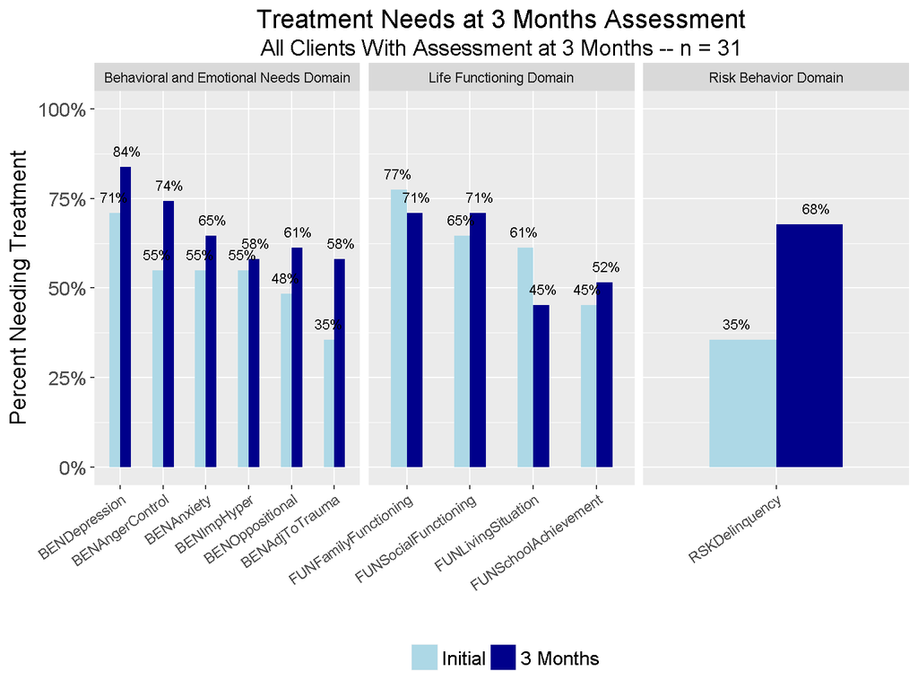

##### 6mo

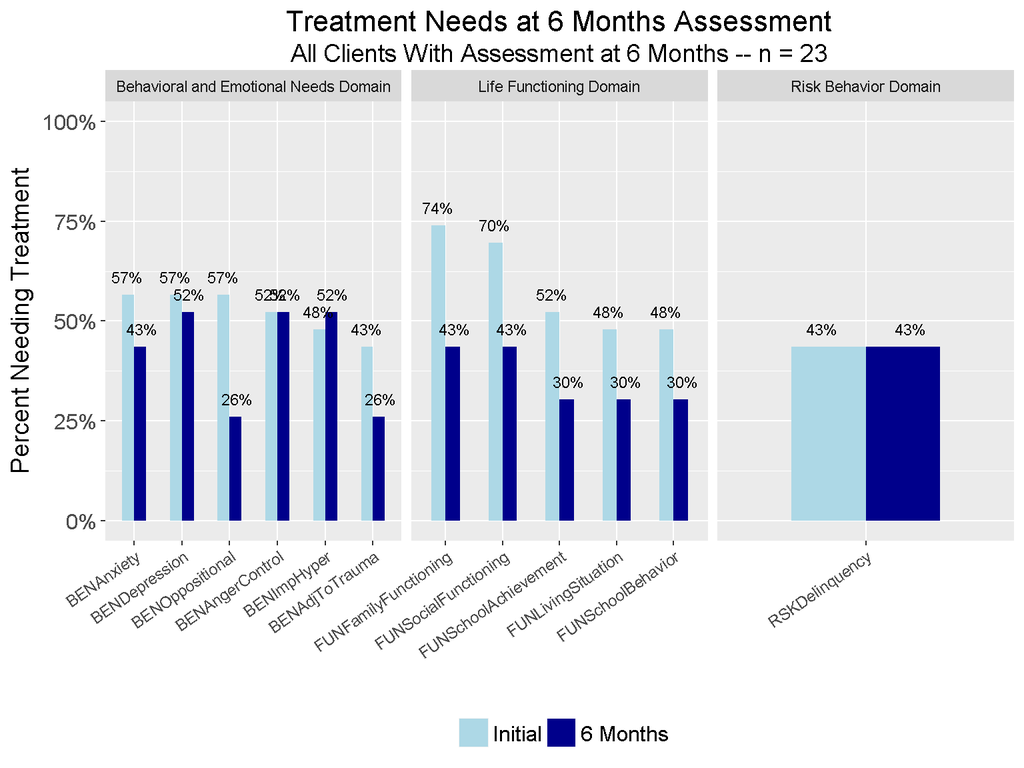

##### 9mo

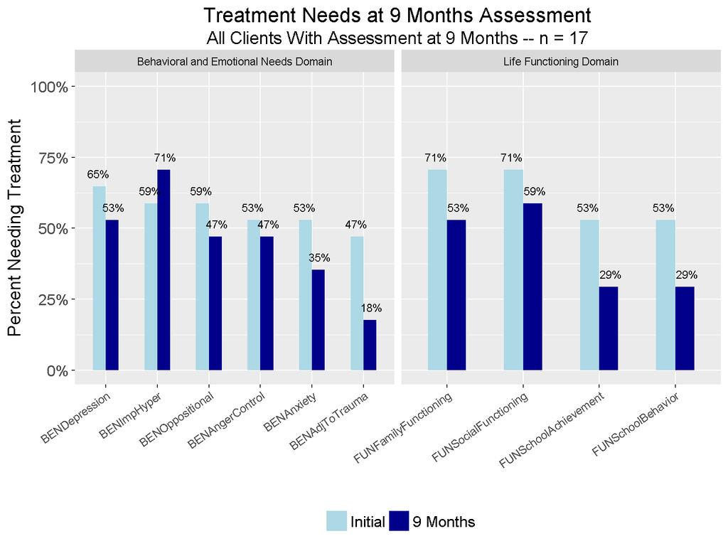

##### 12mo

**A graph cannot be generated, because in the given cohort year and sample, fewer than 10 clients were assessed.**

##### 15mo

**A graph cannot be generated, because in the given cohort year and sample, fewer than 10 clients were assessed.**

##### 18mo

**A graph cannot be generated, because in the given cohort year and sample, fewer than 10 clients were assessed.**

### Discharged After Reassessment

The figures below focus on only clients discharged from care as of the indicated reassessment.

#### 2015 Cohort

##### 3mo

**A graph cannot be generated, because in the given cohort year and sample, fewer than 10 clients were assessed.**

##### 6mo

**A graph cannot be generated, because in the given cohort year and sample, fewer than 10 clients were assessed.**

##### 9mo

**A graph cannot be generated, because in the given cohort year and sample, fewer than 10 clients were assessed.**

#### 2016 Cohort

##### Initial

**A graph cannot be generated, because in the given cohort year and sample, fewer than 10 clients were assessed.**

##### 3mo

**A graph cannot be generated, because in the given cohort year and sample, fewer than 10 clients were assessed.**

##### 6mo

**A graph cannot be generated, because in the given cohort year and sample, fewer than 10 clients were assessed.**

##### 9mo

**A graph cannot be generated, because in the given cohort year and sample, fewer than 10 clients were assessed.**

##### 12mo

**A graph cannot be generated, because in the given cohort year and sample, fewer than 10 clients were assessed.**

#### All Cohort

##### Initial

**A graph cannot be generated, because in the given cohort year and sample, fewer than 10 clients were assessed.**

##### 3mo

**A graph cannot be generated, because in the given cohort year and sample, fewer than 10 clients were assessed.**

##### 6mo

**A graph cannot be generated, because in the given cohort year and sample, fewer than 10 clients were assessed.**

##### 9mo

**A graph cannot be generated, because in the given cohort year and sample, fewer than 10 clients were assessed.**

##### 12mo

**A graph cannot be generated, because in the given cohort year and sample, fewer than 10 clients were assessed.**

### Continuing After Reassessment

The figures below focus on only clients continuing in care as of the indicated reassessment.

#### 2015 Cohort

##### Initial

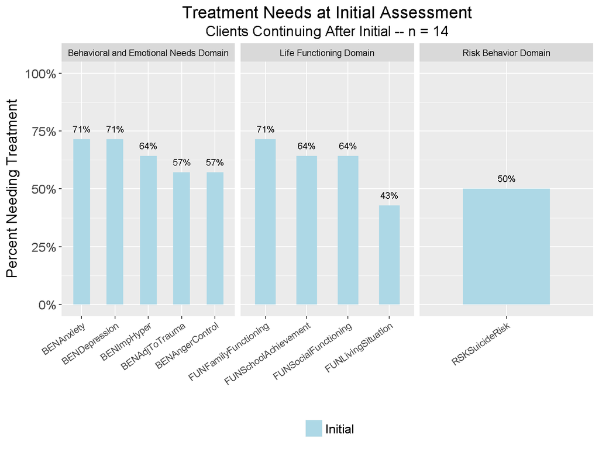

##### 3mo

**A graph cannot be generated, because in the given cohort year and sample, fewer than 10 clients were assessed.**

##### 6mo

**A graph cannot be generated, because in the given cohort year and sample, fewer than 10 clients were assessed.**

##### 9mo

**A graph cannot be generated, because in the given cohort year and sample, fewer than 10 clients were assessed.**

##### 15mo

**A graph cannot be generated, because in the given cohort year and sample, fewer than 10 clients were assessed.**

#### 2016 Cohort

##### Initial

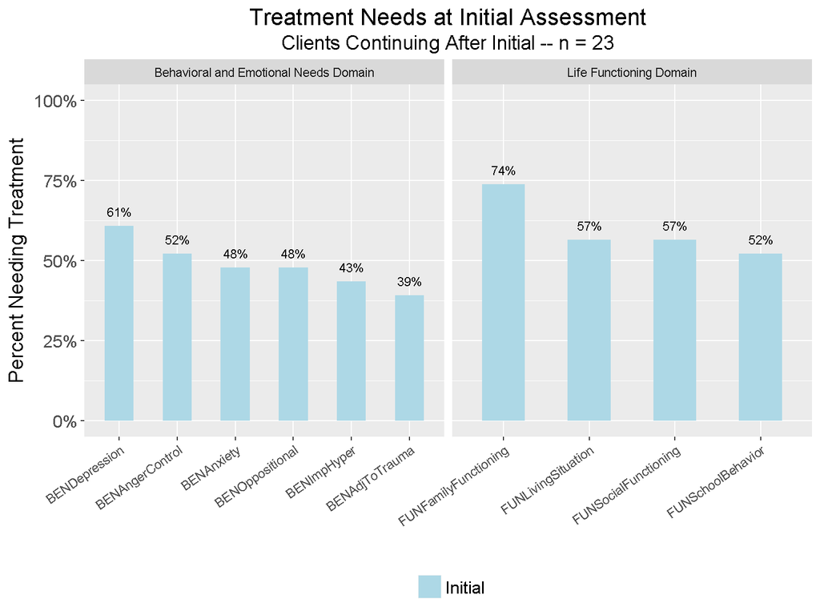

##### 3mo

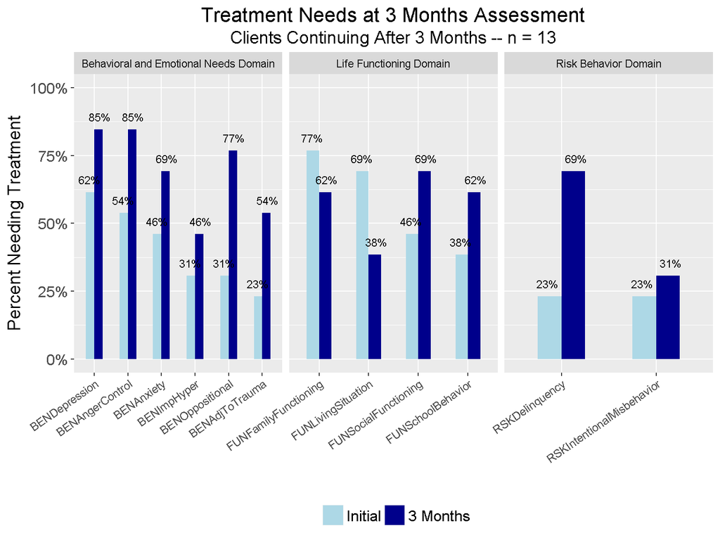

##### 6mo

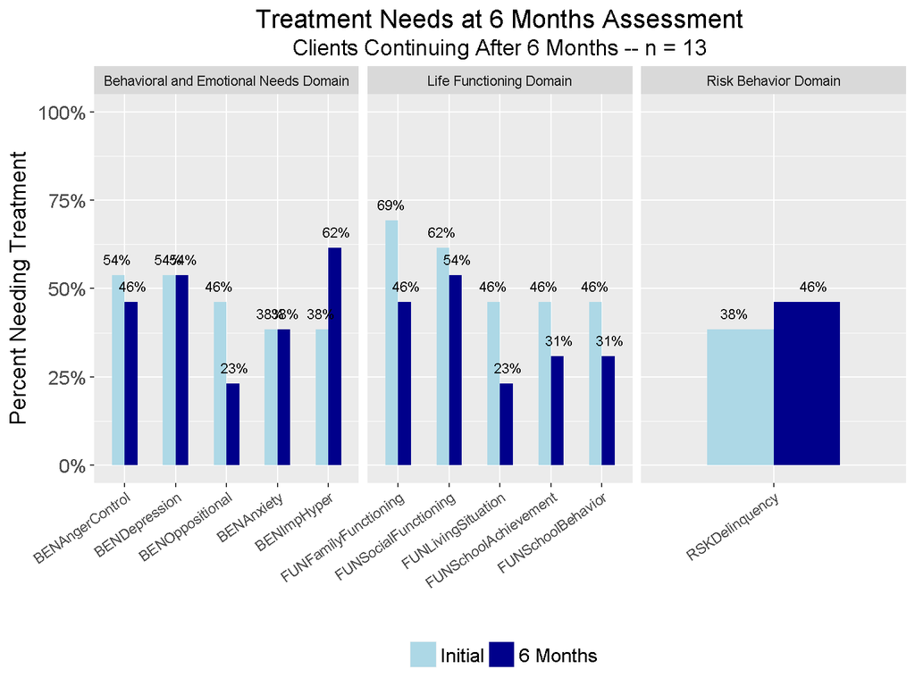

##### 9mo

**A graph cannot be generated, because in the given cohort year and sample, fewer than 10 clients were assessed.**

##### 12mo

**A graph cannot be generated, because in the given cohort year and sample, fewer than 10 clients were assessed.**

##### 15mo

**A graph cannot be generated, because in the given cohort year and sample, fewer than 10 clients were assessed.**

##### 18mo

**A graph cannot be generated, because in the given cohort year and sample, fewer than 10 clients were assessed.**

#### 2017 Cohort

##### Initial

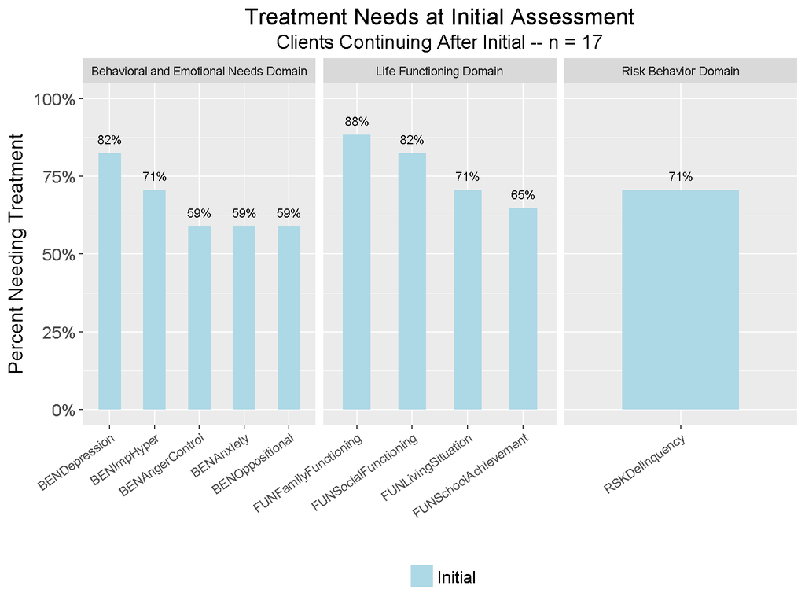

##### 3mo

**A graph cannot be generated, because in the given cohort year and sample, fewer than 10 clients were assessed.**

#### All Cohort

##### Initial

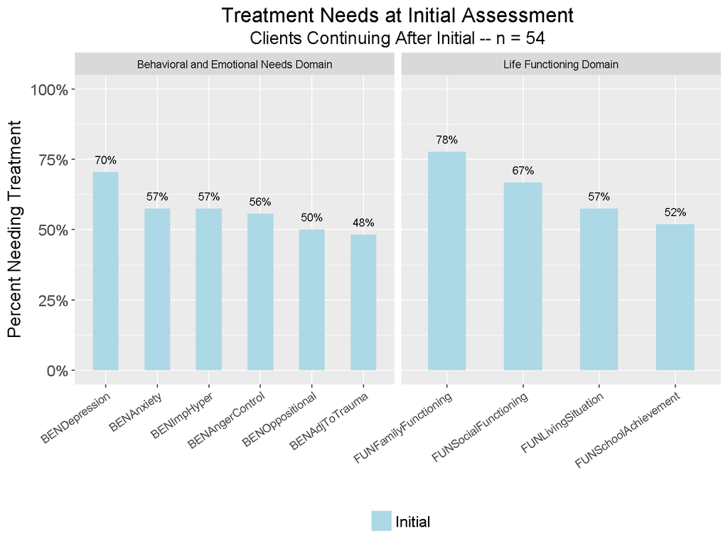

##### 3mo

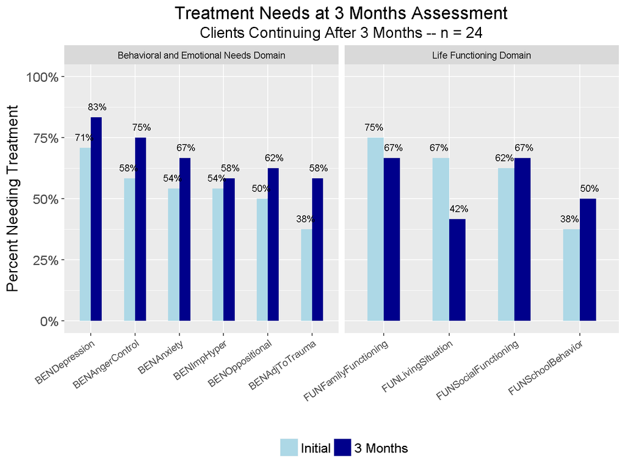

##### 6mo

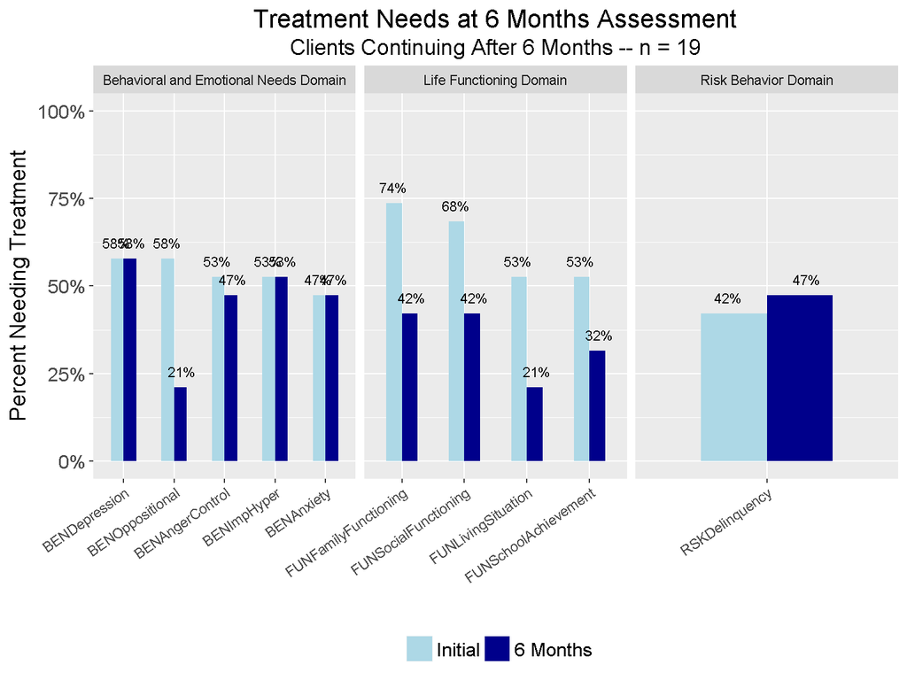

##### 9mo

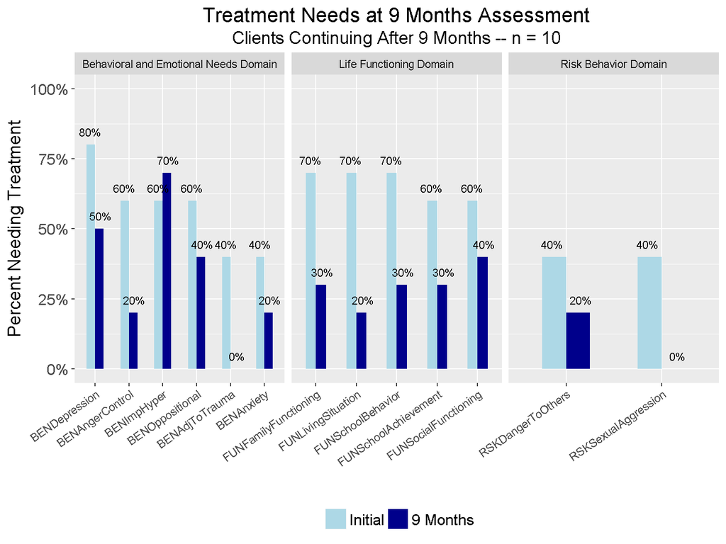

##### 12mo

**A graph cannot be generated, because in the given cohort year and sample, fewer than 10 clients were assessed.**

##### 15mo

**A graph cannot be generated, because in the given cohort year and sample, fewer than 10 clients were assessed.**

##### 18mo

**A graph cannot be generated, because in the given cohort year and sample, fewer than 10 clients were assessed.**